# Lab 4:

Maarten van der Velde

# 1. Preparation

```r
library(mgcv)
library(itsadug)
library(plyr)
library(dplyr)
library(colorspace)
```

Load data

```r
download.file("http://www.jacolienvanrij.com/Courses/LOT2018/data/dat_subset.rda", "dat_subset.rda")
load("dat_subset.rda")
head(dat)
```

|  | Event | Subject | TRIAL_INDEX | timebin | TIMESTAMP | Frequency | Item | KEY_RT | Length | Stimulus | Stimulus_Duration | Time | GAZE_X | GAZE_Y | INTEREST_AREA_ID | INTEREST_AREA_LABEL | IN_BLINK | IN_SACCADE | PUPIL_SIZE | start.event | recFreq | PUPIL_SIZE_clean | median_PUPIL_SIZE_clean | median_GAZE_X | median_GAZE_Y | median_INTEREST_AREA_ID | median_IN_BLINK | median_IN_SACCADE | FixCrossMessage | … |
| --- | --- | --- | --- | --- | --- | --- | --- | --- | --- | --- | --- | --- | --- | --- | --- | --- | --- | --- | --- | --- | --- | --- | --- | --- | --- | --- | --- | --- | --- | --- |
| 1 | 002_ld.5 | 002_ld | 5 | -730 | 3632626 | 45.12 | 93 | 549.7587 | 6 | stim86 | 1500 | -732 | 984.1 | 557.5 | 1 | 1 | 0 | 0 | 549 | TRUE | 500 | 549 | 550.5 | 984.00 | 558.35 | 1 | FALSE | FALSE | 3632858 | … |
| 2 | 002_ld.5 | 002_ld | 5 | -710 | 3632646 | 45.12 | 93 | 549.7587 | 6 | stim86 | 1500 | -712 | 984.7 | 558.9 | 1 | 1 | 0 | 0 | 551 | FALSE | 500 | 551 | 551.0 | 984.55 | 559.20 | 1 | FALSE | FALSE | 3632858 | … |
| 3 | 002_ld.5 | 002_ld | 5 | -690 | 3632666 | 45.12 | 93 | 549.7587 | 6 | stim86 | 1500 | -692 | 983.0 | 562.6 | 1 | 1 | 0 | 0 | 552 | FALSE | 500 | 552 | 552.5 | 983.30 | 562.95 | 1 | FALSE | FALSE | 3632858 | … |
| 4 | 002_ld.5 | 002_ld | 5 | -670 | 3632686 | 45.12 | 93 | 549.7587 | 6 | stim86 | 1500 | -672 | 980.8 | 562.9 | 1 | 1 | 0 | 0 | 553 | FALSE | 500 | 553 | 553.0 | 980.45 | 563.10 | 1 | FALSE | FALSE | 3632858 | … |
| 5 | 002_ld.5 | 002_ld | 5 | -650 | 3632706 | 45.12 | 93 | 549.7587 | 6 | stim86 | 1500 | -652 | 978.3 | 564.9 | 1 | 1 | 0 | 0 | 555 | FALSE | 500 | 555 | 555.0 | 978.45 | 564.05 | 1 | FALSE | FALSE | 3632858 | … |
| 6 | 002_ld.5 | 002_ld | 5 | -630 | 3632726 | 45.12 | 93 | 549.7587 | 6 | stim86 | 1500 | -632 | 982.4 | 560.4 | 1 | 1 | 0 | 0 | 554 | FALSE | 500 | 554 | 554.5 | 982.60 | 560.85 | 1 | FALSE | FALSE | 3632858 | … |

```r
str(dat)
```

```
'data.frame':   44696 obs. of  38 variables:
 $ Event                  : Factor w/ 275 levels "002_ld.5","003_ld.5",..: 1 1 1 1 1 1 1 1 1 1 ...
 $ Subject                : Factor w/ 11 levels "002_ld","003_ld",..: 1 1 1 1 1 1 1 1 1 1 ...
 $ TRIAL_INDEX            : int  5 5 5 5 5 5 5 5 5 5 ...
 $ timebin                : num  -730 -710 -690 -670 -650 -630 -610 -590 -570 -550 ...
 $ TIMESTAMP              : num  3632626 3632646 3632666 3632686 3632706 ...
 $ Frequency              : num  45.1 45.1 45.1 45.1 45.1 ...
 $ Item                   : Factor w/ 194 levels "10","101","102",..: 188 188 188 188 188 188 188 188 188 188 ...
 $ KEY_RT                 : num  550 550 550 550 550 ...
 $ Length                 : num  6 6 6 6 6 6 6 6 6 6 ...
 $ Stimulus               : Factor w/ 230 levels "stim1","stim2",..: 86 86 86 86 86 86 86 86 86 86 ...
 $ Stimulus_Duration      : num  1500 1500 1500 1500 1500 ...
 $ Time                   : num  -732 -712 -692 -672 -652 -632 -612 -592 -572 -552 ...
 $ GAZE_X                 : num  984 985 983 981 978 ...
 $ GAZE_Y                 : num  558 559 563 563 565 ...
```

[output cut: 24 more lines]

```r
summary(dat$Time)
```

```
   Min. 1st Qu.  Median    Mean 3rd Qu.    Max.
 -750.0    68.0   874.0   875.9  1690.0  2498.0
```

Convert to factors

```r
dat <- dat %>%
  mutate(StimType = as.factor(StimType))
```

## Nonlinear interaction using `ti()`

```r
m2 <- bam(Pupil ~ StimType + s(Time, by=StimType)
          + s(Time, Subject, bs='fs', m=1)
          + s(Time, Item, bs='fs', m=1), data=dat, discrete = TRUE)
```

```
model has repeated 1-d smooths of same variable.
```

```r
summary(m2)
```

```
Family: gaussian
Link function: identity

Formula:
Pupil ~ StimType + s(Time, by = StimType) + s(Time, Subject,
    bs = "fs", m = 1) + s(Time, Item, bs = "fs", m = 1)

Parametric coefficients:
             Estimate Std. Error t value Pr(>|t|)
(Intercept)   24.8845     6.4023   3.887 0.000102 ***
StimTypeword  -4.0616     0.4546  -8.935  < 2e-16 ***
---
Signif. codes:  0 ‘***’ 0.001 ‘**’ 0.01 ‘*’ 0.05 ‘.’ 0.1 ‘ ’ 1

Approximate significance of smooth terms:
                                edf   Ref.df       F  p-value
s(Time):StimTypepseudoword    6.382    6.807   7.196 4.87e-08 ***
s(Time):StimTypeword          7.252    7.667   7.641 4.35e-10 ***
s(Time,Subject)              90.072   98.000 143.810  < 2e-16 ***
s(Time,Item)               1576.235 1745.000  66.859  < 2e-16 ***
---
Signif. codes:  0 ‘***’ 0.001 ‘**’ 0.01 ‘*’ 0.05 ‘.’ 0.1 ‘ ’ 1

R-sq.(adj) =  0.792   Deviance explained =   80%
fREML = 1.9724e+05  Scale est. = 602.54    n = 42029
```

Include the predictor `wordLength` and the interaction between `Time` and `wordLength`.

```r
m3 <- bam(Pupil ~ StimType +
            s(wordLength, by = StimType) +
            s(Time, by = StimType) +
            ti(wordLength, Time, by = StimType) +
            s(Time, Subject, bs='fs', m=1) +
            s(Time, Item, bs='fs', m=1),
          data=dat, discrete = TRUE)
summary(m3)
```

```
Family: gaussian
Link function: identity

Formula:
Pupil ~ StimType + s(wordLength, by = StimType) + s(Time, by = StimType) +
    ti(wordLength, Time, by = StimType) + s(Time, Subject, bs = "fs",
    m = 1) + s(Time, Item, bs = "fs", m = 1)

Parametric coefficients:
             Estimate Std. Error t value Pr(>|t|)
(Intercept)    -5.089      9.195  -0.553  0.57997
StimTypeword 1890.946    715.335   2.643  0.00821 **
---
Signif. codes:  0 ‘***’ 0.001 ‘**’ 0.01 ‘*’ 0.05 ‘.’ 0.1 ‘ ’ 1

Approximate significance of smooth terms:
                                            edf   Ref.df       F  p-value
s(wordLength):StimTypepseudoword          8.153    8.172   5.859 8.13e-07 ***
s(wordLength):StimTypeword                7.984    8.006   5.162 1.13e-06 ***
s(Time):StimTypepseudoword                6.580    6.956   5.037 1.44e-05 ***
s(Time):StimTypeword                      7.351    7.738  17.858  < 2e-16 ***
ti(wordLength,Time):StimTypepseudoword    8.932    9.391   2.697  0.00284 **
ti(wordLength,Time):StimTypeword         13.834   14.314  20.266  < 2e-16 ***
s(Time,Subject)                          89.866   98.000 152.911  < 2e-16 ***
s(Time,Item)                           1568.277 1745.000  61.215  < 2e-16 ***
---
Signif. codes:  0 ‘***’ 0.001 ‘**’ 0.01 ‘*’ 0.05 ‘.’ 0.1 ‘ ’ 1

R-sq.(adj) =  0.804   Deviance explained = 81.2%
fREML = 1.9615e+05  Scale est. = 567.47    n = 42029
```

## Question 1: nonlinear interactions

**Does the nonlinear interaction contribute to the model?**

Yes. The interaction is a signifant effect and the model explains more of the variance in the data.

## Visualising nonlinear interactions

```r
pvisgam(m3, view=c("Time", "wordLength"), select=4, color=terrain_hcl(50))
```

```
[1] "Tensor(s) to be plotted: s(Time):StimTypeword"
```

```
data length [31] is not a sub-multiple or multiple of the number of rows [30]
```

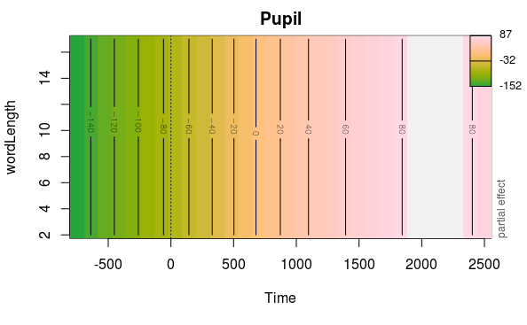

```r
abline(v=0, lty=3)
```

```r
fvisgam(m3, view=c("Time", "wordLength"), rm.ranef=TRUE, color=terrain_hcl(50))
```

```
Summary:
    * StimType : factor; set to the value(s): pseudoword.
    * wordLength : numeric predictor; with 30 values ranging from 2.000000 to 17.000000.
    * Time : numeric predictor; with 30 values ranging from -750.000000 to 2498.000000.
    * Subject : factor; set to the value(s): 002_ld. (Might be canceled as random effect, check below.)
    * Item : factor; set to the value(s): 171. (Might be canceled as random effect, check below.)
    * NOTE : The following random effects columns are canceled: s(Time,Subject),s(Time,Item)
```

```
data length [31] is not a sub-multiple or multiple of the number of rows [30]
```

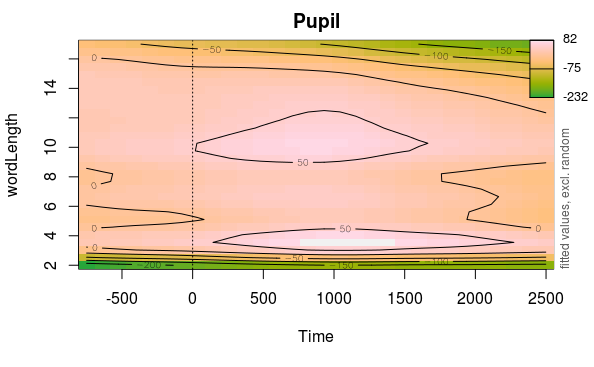

```r
abline(v=0, lty=3)
```

## Question 2: visualising nonlinear interactions

**What is the difference between the two functions?**

`pvisgam` plots the partial effects, in this case we only see the effect of the time smooth for ‘word’ stimuli. It shows that the pupil size increases over time.

`fvisgam` plots the summed fitted effects (i.e., the actual model prediction). If not specified, it just chooses a level for each factor (here `StimType` is set to pseudoword). Random effects can be included or not (here they are excluded).

## Nonlinear interactions using `te()`

We can replace the separate smooths and `ti()` term with a single `te()` term. For simplicity, ignore the `StimType` predictor for now.

```r
m4a <- bam(Pupil ~ s(Time) + s(wordLength) + ti(Time, wordLength)
          + s(Time, Subject, bs='fs', m=1)
          + s(Time, Item, bs='fs', m=1), data=dat, discrete = TRUE, nthreads = 3)
m4b <- bam(Pupil ~ te(Time, wordLength)
          + s(Time, Subject, bs='fs', m=1)
          + s(Time, Item, bs='fs', m=1), data=dat, discrete = TRUE, nthreads = 3)
summary(m4a)
```

```
Family: gaussian
Link function: identity

Formula:
Pupil ~ s(Time) + s(wordLength) + ti(Time, wordLength) + s(Time,
    Subject, bs = "fs", m = 1) + s(Time, Item, bs = "fs", m = 1)

Parametric coefficients:
            Estimate Std. Error t value Pr(>|t|)
(Intercept)    10.70       7.59    1.41    0.159

Approximate significance of smooth terms:
                         edf   Ref.df       F  p-value
s(Time)                6.813    7.044   6.342 8.72e-07 ***
s(wordLength)          3.379    3.396   5.918 0.000272 ***
ti(Time,wordLength)    4.614    4.879   2.777 0.017265 *
s(Time,Subject)       89.053   98.000 143.486  < 2e-16 ***
s(Time,Item)        1566.823 1745.000  59.716  < 2e-16 ***
---
Signif. codes:  0 ‘***’ 0.001 ‘**’ 0.01 ‘*’ 0.05 ‘.’ 0.1 ‘ ’ 1

R-sq.(adj) =  0.791   Deviance explained = 79.9%
fREML = 1.9727e+05  Scale est. = 604.32    n = 42029
```

```r
summary(m4b)
```

```
Family: gaussian
Link function: identity

Formula:
Pupil ~ te(Time, wordLength) + s(Time, Subject, bs = "fs", m = 1) +
    s(Time, Item, bs = "fs", m = 1)

Parametric coefficients:
            Estimate Std. Error t value Pr(>|t|)
(Intercept)   11.486      7.277   1.578    0.114

Approximate significance of smooth terms:
                        edf  Ref.df       F  p-value
te(Time,wordLength)   14.19   14.64   6.895 1.57e-14 ***
s(Time,Subject)       91.35   98.00 143.690  < 2e-16 ***
s(Time,Item)        1564.54 1745.00  60.989  < 2e-16 ***
---
Signif. codes:  0 ‘***’ 0.001 ‘**’ 0.01 ‘*’ 0.05 ‘.’ 0.1 ‘ ’ 1

R-sq.(adj) =  0.791   Deviance explained = 79.9%
fREML = 1.9727e+05  Scale est. = 604.42    n = 42029
```

Although the models are comparable, they are not identical, as the plotted estimates show. The `te()` version of the model is noticeably smoother, since it has fewer degrees of freedom to work with. In this case that might actually be a good thing, since the less constrained model predicts an effect of word length on pupil size before the word has even appeared, which should not be possible.

```r
par(mfrow=c(1,2))
fvisgam(m4a, view=c("Time", "wordLength"), rm.ranef=TRUE, color=terrain_hcl(50))
```

```
Summary:
    * Time : numeric predictor; with 30 values ranging from -750.000000 to 2498.000000.
    * wordLength : numeric predictor; with 30 values ranging from 2.000000 to 17.000000.
    * Subject : factor; set to the value(s): 002_ld. (Might be canceled as random effect, check below.)
    * Item : factor; set to the value(s): 171. (Might be canceled as random effect, check below.)
    * NOTE : The following random effects columns are canceled: s(Time,Subject),s(Time,Item)
```

```
data length [31] is not a sub-multiple or multiple of the number of rows [30]
```

```r
abline(v=0, lty=3)
```

```r
fvisgam(m4b, view=c("Time", "wordLength"), rm.ranef=TRUE, color=terrain_hcl(50))
```

```
Summary:
    * Time : numeric predictor; with 30 values ranging from -750.000000 to 2498.000000.
    * wordLength : numeric predictor; with 30 values ranging from 2.000000 to 17.000000.
    * Subject : factor; set to the value(s): 002_ld. (Might be canceled as random effect, check below.)
    * Item : factor; set to the value(s): 171. (Might be canceled as random effect, check below.)
    * NOTE : The following random effects columns are canceled: s(Time,Subject),s(Time,Item)
```

```
data length [31] is not a sub-multiple or multiple of the number of rows [30]
```

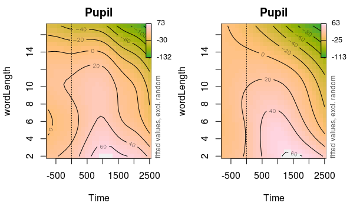

```r
abline(v=0, lty=3)
```

## Question 3: `ti()` vs `te()`

**Translate `StimType + te(Time, wordLength, by=StimType)` to a comparable model formula with `ti` and `s`.**

`StimType + s(Time, by = StimType) + s(wordLength, by = StimType) + ti(Time, wordLength, by StimType)`

## Nonlinear interaction using `s()`

`s()` is used when the interacting predictors are isotropic (measured on the same scale and dimension).

Include a nonlinear interaction between gaze x and y coordinates:

```r
m5 <- bam(Pupil ~ StimType + s(Time, by=StimType) + s(wordLength)
          + ti(Time, wordLength)
          + s(median_GAZE_X, median_GAZE_Y)
          + s(Time, Subject, bs='fs', m=1)
          + s(Time, Item, bs='fs', m=1), data=dat, discrete = TRUE, nthreads = 4)
summary(m5)
```

```
Family: gaussian
Link function: identity

Formula:
Pupil ~ StimType + s(Time, by = StimType) + s(wordLength) + ti(Time,
    wordLength) + s(median_GAZE_X, median_GAZE_Y) + s(Time, Subject,
    bs = "fs", m = 1) + s(Time, Item, bs = "fs", m = 1)

Parametric coefficients:
             Estimate Std. Error t value Pr(>|t|)
(Intercept)    27.292     22.681   1.203    0.229
StimTypeword   -3.166      0.442  -7.164 7.99e-13 ***
---
Signif. codes:  0 ‘***’ 0.001 ‘**’ 0.01 ‘*’ 0.05 ‘.’ 0.1 ‘ ’ 1

Approximate significance of smooth terms:
                                    edf   Ref.df       F  p-value
s(Time):StimTypepseudoword        5.732    6.185   5.572 4.72e-06 ***
s(Time):StimTypeword              7.359    7.796   6.863 6.52e-08 ***
s(wordLength)                     3.608    3.627   6.243 0.000122 ***
ti(Time,wordLength)               4.894    5.162   2.927 0.012396 *
s(median_GAZE_X,median_GAZE_Y)   26.689   27.559 115.406  < 2e-16 ***
s(Time,Subject)                  90.402   98.000 145.407  < 2e-16 ***
s(Time,Item)                   1566.999 1744.000  59.423  < 2e-16 ***
---
Signif. codes:  0 ‘***’ 0.001 ‘**’ 0.01 ‘*’ 0.05 ‘.’ 0.1 ‘ ’ 1

R-sq.(adj) =  0.806   Deviance explained = 81.4%
fREML = 1.9577e+05  Scale est. = 559.86    n = 42029
```

Inspect the effect of gaze position on pupil size by visualising the partial effect:

```r
pvisgam(m5, view=c("median_GAZE_X", "median_GAZE_Y"), select=5, color=terrain_hcl(50))
```

```
[1] "Tensor(s) to be plotted: s(median_GAZE_X,median_GAZE_Y)"
```

```
data length [31] is not a sub-multiple or multiple of the number of rows [30]
```

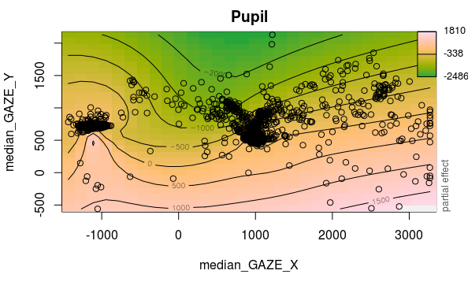

```r
points(dat$median_GAZE_X, dat$median_GAZE_Y)
```

## Question 4: Gaze position

**Describe the effect of gaze position on pupil size.**

It is not clear what the coordinate system is (is (0,0) the start of the word, the center of the screen, or something else?). Nevertheless we can see a fairly strong effect of the y-coordinate on pupil size: as participants look towards the top of the screen, their pupil becomes smaller. There is possibly also a weak interaction with the x-coordinate, which is especially visible when participants look towards the right of the screen.

**What is your conclusion? Do you see any problems?**

Aside from the issue that we don’t know what the coordinates mean, the variation in pupil size is extremely big and occurs largely in one direction (vertically), which is suspicious.